# Practica7_JSQ

Jessica Santiago Quijano

2022-03-23

# 1 Carga y analiza la estructura e información del data frame usando str

```r
datos_art <- read.csv(file = "Estudiantes.csv",header = TRUE)
str(datos_art)
```

```
## 'data.frame':    400 obs. of  46 variables:
##  $ Observacion : int  1 2 3 4 5 6 7 8 9 10 ...
##  $ ID          : chr  "SB11201910010435" "SB11201910004475" "SB11201910011427" "SB11201910041975" ...
##  $ Sexo        : chr  "Femenino" "Masculino" "Masculino" "Masculino" ...
##  $ SexoNum     : int  0 1 1 1 0 0 0 0 0 1 ...
##  $ Edad        : num  21.4 21.1 20.9 18.4 16.6 ...
##  $ Fuma        : chr  "No" "Si" "Si" "Si" ...
##  $ Estatura    : chr  "Alta" "Baja" "Alta" "Alta" ...
##  $ Colegio     : chr  "Privado" "Privado" "Privado" "Privado" ...
##  $ Estrato     : int  1 2 2 2 1 2 1 1 2 1 ...
##  $ Financiacion: chr  "Beca" "Beca" "Beca" "Beca" ...
##  $ Acumulado   : num  3.92 3.96 3.85 3.69 4.01 3.8 4.35 3.76 3.57 3.15 ...
##  $ P1          : num  1.5 2.3 3.4 2.5 3.1 3.8 5 4 2.5 2.4 ...
##  $ P2          : num  5 4.9 3.6 4.2 3.5 4.4 3 2.3 3.3 2.6 ...
##  $ P3          : num  5 3.7 2 5 5 4.2 3.5 4.6 3.8 4.3 ...
```

[output cut: 32 more lines]

# 2 Muestra el nombre de las variables

```r
names(datos_art)
```

```
##  [1] "Observacion"  "ID"           "Sexo"         "SexoNum"      "Edad"
##  [6] "Fuma"         "Estatura"     "Colegio"      "Estrato"      "Financiacion"
## [11] "Acumulado"    "P1"           "P2"           "P3"           "Final"
## [16] "Definitiva"   "Gastos"       "Ingreso"      "Gas"          "Clases"
## [21] "Ley"          "PandemiaCat"  "PandemiaNum"  "Likert1"      "Likert2"
## [26] "Likert3"      "Likert4"      "Likert5"      "AGPEQ1"       "AGPEQ2"
## [31] "AGPEQ3"       "SATS1"        "SATS2"        "SATS3"        "SATS4"
## [36] "IDARE1.1"     "IDARE1.2"     "IDARE1.3"     "IDARE1.4"     "IDARE1.5"
## [41] "IDARE2.6"     "IDARE2.7"     "IDARE2.8"     "IDARE2.9"     "IDARE2.10"
## [46] "Puntaje"
```

# 3 Muestra información de tamaños, en cuanto tamaño del archivo, dimesiones (fila, columna)

```r
object.size(datos_art)
```

```
## 175680 bytes
```

```r
dim(datos_art)
```

```
## [1] 400  46
```

# 4 Muestra el conjunto de la fila 1-10 y de la columna 2-5 y realiza las instrucciones del 4.1 al 4.8

```r
conjunto <- datos_art[1:10, 2:5]
conjunto
```

```
##                  ID      Sexo SexoNum  Edad
## 1  SB11201910010435  Femenino       0 21.36
## 2  SB11201910004475 Masculino       1 21.07
## 3  SB11201910011427 Masculino       1 20.92
## 4  SB11201910041975 Masculino       1 18.41
## 5  SB11201910013623  Femenino       0 16.64
## 6  SB11201910038122  Femenino       0 16.02
## 7  SB11201910037905  Femenino       0 19.32
## 8  SB11201910038140  Femenino       0 18.62
## 9  SB11201910038005  Femenino       0 17.01
## 10 SB11201910037919 Masculino       1 19.71
```

## 4.1 Sola la fila 3 y columna 2

```r
incisoa <- conjunto [3,2]
incisoa
```

```
## [1] "Masculino"
```

## 4.2 Todas las filas y solo la columna 2

```r
incisob <- conjunto [,2]
incisob
```

```
##  [1] "Femenino"  "Masculino" "Masculino" "Masculino" "Femenino"  "Femenino"
##  [7] "Femenino"  "Femenino"  "Femenino"  "Masculino"
```

## 4.3 Solo la fila 3 y todas las columnas

```r
incisoc <- conjunto [3,]
incisoc
```

```
##                 ID      Sexo SexoNum  Edad
## 3 SB11201910011427 Masculino       1 20.92
```

## 4.4 Quitar la fila 5 y dejar todas las columnas

```r
incisod<- conjunto [-5,]
incisod
```

```
##                  ID      Sexo SexoNum  Edad
## 1  SB11201910010435  Femenino       0 21.36
## 2  SB11201910004475 Masculino       1 21.07
## 3  SB11201910011427 Masculino       1 20.92
## 4  SB11201910041975 Masculino       1 18.41
## 6  SB11201910038122  Femenino       0 16.02
## 7  SB11201910037905  Femenino       0 19.32
## 8  SB11201910038140  Femenino       0 18.62
## 9  SB11201910038005  Femenino       0 17.01
## 10 SB11201910037919 Masculino       1 19.71
```

## 4.5 Todas las filas, pero sin la columna dos

```r
incisoe<- conjunto [,-2]
incisoe
```

```
##                  ID SexoNum  Edad
## 1  SB11201910010435       0 21.36
## 2  SB11201910004475       1 21.07
## 3  SB11201910011427       1 20.92
## 4  SB11201910041975       1 18.41
## 5  SB11201910013623       0 16.64
## 6  SB11201910038122       0 16.02
## 7  SB11201910037905       0 19.32
## 8  SB11201910038140       0 18.62
## 9  SB11201910038005       0 17.01
## 10 SB11201910037919       1 19.71
```

```r
incisof<- conjunto [,2:4]
incisof
```

```
##         Sexo SexoNum  Edad
## 1   Femenino       0 21.36
## 2  Masculino       1 21.07
## 3  Masculino       1 20.92
## 4  Masculino       1 18.41
## 5   Femenino       0 16.64
## 6   Femenino       0 16.02
## 7   Femenino       0 19.32
## 8   Femenino       0 18.62
## 9   Femenino       0 17.01
## 10 Masculino       1 19.71
```

```r
incisog<- conjunto [,c(2,4)]
incisog
```

```
##         Sexo  Edad
## 1   Femenino 21.36
## 2  Masculino 21.07
## 3  Masculino 20.92
## 4  Masculino 18.41
## 5   Femenino 16.64
## 6   Femenino 16.02
## 7   Femenino 19.32
## 8   Femenino 18.62
## 9   Femenino 17.01
## 10 Masculino 19.71
```

```r
incisoh<- conjunto [1:4,c(2,4)]
incisoh
```

```
##        Sexo  Edad
## 1  Femenino 21.36
## 2 Masculino 21.07
## 3 Masculino 20.92
## 4 Masculino 18.41
```

# 5 Tipos de variables

## 5.1 Verifica el tipo de datos de la variable ID, Edad y Sexo. Si ID es de tipo carácter es correcto, si Edad y Sexo son de tipo carácter son incorrectas

```r
sapply(select(datos_art, ID, Edad, Sexo), class)
```

```
##          ID        Edad        Sexo
## "character"   "numeric" "character"
```

## 5.2 Convierte la variable Edad a tipo númerico

```r
edad <- transform(datos_art, Edad = as.numeric(Edad))
edad
```

```
##     Observacion               ID      Sexo SexoNum  Edad Fuma Estatura Colegio
## 1             1 SB11201910010435  Femenino       0 21.36   No     Alta Privado
## 2             2 SB11201910004475 Masculino       1 21.07   Si     Baja Privado
## 3             3 SB11201910011427 Masculino       1 20.92   Si     Alta Privado
## 4             4 SB11201910041975 Masculino       1 18.41   Si     Alta Privado
## 5             5 SB11201910013623  Femenino       0 16.64   Si     Alta Privado
## 6             6 SB11201910038122  Femenino       0 16.02   No     Baja Privado
## 7             7 SB11201910037905  Femenino       0 19.32   Si     Baja Privado
## 8             8 SB11201910038140  Femenino       0 18.62   Si    Media Privado
## 9             9 SB11201910038005  Femenino       0 17.01   Si    Media Privado
## 10           10 SB11201910037919 Masculino       1 19.71   Si    Media Privado
## 11           11 SB11201910038100  Femenino       0 20.75   No    Media Privado
## 12           12 SB11201910038016  Femenino       0 16.69   Si    Media Privado
## 13           13 SB11201910037882 Masculino       1 18.16   Si    Media Privado
## 14           14 SB11201910037986  Femenino       0 18.72   Si    Media Privado
```

[output cut: 3594 more lines]

## 5.3 Convierte la variable Sexo a Factor

```r
sexo <- transform(datos_art, Sexo = as.factor(Sexo))
sexo
```

```
##     Observacion               ID      Sexo SexoNum  Edad Fuma Estatura Colegio
## 1             1 SB11201910010435  Femenino       0 21.36   No     Alta Privado
## 2             2 SB11201910004475 Masculino       1 21.07   Si     Baja Privado
## 3             3 SB11201910011427 Masculino       1 20.92   Si     Alta Privado
## 4             4 SB11201910041975 Masculino       1 18.41   Si     Alta Privado
## 5             5 SB11201910013623  Femenino       0 16.64   Si     Alta Privado
## 6             6 SB11201910038122  Femenino       0 16.02   No     Baja Privado
## 7             7 SB11201910037905  Femenino       0 19.32   Si     Baja Privado
## 8             8 SB11201910038140  Femenino       0 18.62   Si    Media Privado
## 9             9 SB11201910038005  Femenino       0 17.01   Si    Media Privado
## 10           10 SB11201910037919 Masculino       1 19.71   Si    Media Privado
## 11           11 SB11201910038100  Femenino       0 20.75   No    Media Privado
## 12           12 SB11201910038016  Femenino       0 16.69   Si    Media Privado
## 13           13 SB11201910037882 Masculino       1 18.16   Si    Media Privado
## 14           14 SB11201910037986  Femenino       0 18.72   Si    Media Privado
```

[output cut: 3594 more lines]

# 6 Tablas univariadas

## 6.1 Construir una tabla de frecuencias para analizar la distribución de la variable categórica Sexo.

```r
#Definiendo y convirtiendo en factor
Sexo <- as.factor(datos_art$Sexo)

#Calcular tabla de frecuencias
Tabla1 <- table(Sexo); Tabla1
```

```
## Sexo
##  Femenino Masculino
##       211       189
```

# 7 Tabla cruzada o de contingencia

## 7.1 Construir una tabla de frecuencias para analizar la distribución conjunta de las variables categóricas Sexo y Fuma

```r
#Definiendo y convirtiendo en factor
Sexo <- as.factor(datos_art$Sexo)
Fuma <- as.factor(datos_art$Fuma)

#Tabla de frecuencias con table
Tabla2 <- table(Sexo,Fuma); Tabla2
```

```
##            Fuma
## Sexo         No  Si
##   Femenino  116  95
##   Masculino 109  80
```

### 7.1.1 Gráfico de barras de la tabla cruzada

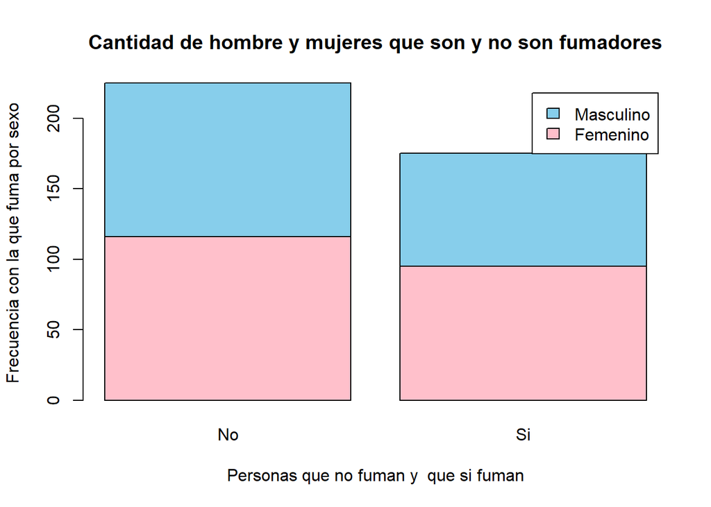

```r
barplot(Tabla2, benside = F,
        main = 'Cantidad de hombre y mujeres que son y no son fumadores',
        xlab = 'Personas que no fuman y  que si fuman', horiz = FALSE,
        ylab = 'Frecuencia con la que fuma por sexo',
        legend = c ("Femenino", "Masculino"),
        col = c("pink", "sky blue"))
```

# 8 SEGUNDA PARTE

## 8.1 Considerar solamente las observaciones que van desde la 2 hasta la 193 y las variables que van desde la 5 hasta la 15 y las variables 20 y 35

```r
MisDatos <- datos_art [2:193,c(5:15,20,35)]
MisDatos
```

```
##      Edad Fuma Estatura Colegio Estrato Financiacion Acumulado  P1  P2  P3
## 2   21.07   Si     Baja Privado       2         Beca      3.96 2.3 4.9 3.7
## 3   20.92   Si     Alta Privado       2         Beca      3.85 3.4 3.6 2.0
## 4   18.41   Si     Alta Privado       2         Beca      3.69 2.5 4.2 5.0
## 5   16.64   Si     Alta Privado       1         Beca      4.01 3.1 3.5 5.0
## 6   16.02   No     Baja Privado       2         Beca      3.80 3.8 4.4 4.2
## 7   19.32   Si     Baja Privado       1         Beca      4.35 5.0 3.0 3.5
## 8   18.62   Si    Media Privado       1         Beca      3.76 4.0 2.3 4.6
## 9   17.01   Si    Media Privado       2         Beca      3.57 2.5 3.3 3.8
## 10  19.71   Si    Media Privado       1         Beca      3.15 2.4 2.6 4.3
## 11  20.75   No    Media Privado       1         Beca      3.80 2.7 4.0 3.0
## 12  16.69   Si    Media Privado       1         Beca      3.09 2.7 2.3 3.8
## 13  18.16   Si    Media Privado       2         Beca      3.65 3.0 4.1 3.4
## 14  18.72   Si    Media Privado       1         Beca      3.13 2.7 2.3 3.3
## 15  19.79   No    Media Privado       1         Beca      3.49 2.8 2.3 3.5
```

[output cut: 371 more lines]

## 8.2 Visualizar los primeros 6 registros del subconjunto de datos

```r
head(MisDatos,6)
```

```
##    Edad Fuma Estatura Colegio Estrato Financiacion Acumulado  P1  P2  P3 Final
## 2 21.07   Si     Baja Privado       2         Beca      3.96 2.3 4.9 3.7   3.3
## 3 20.92   Si     Alta Privado       2         Beca      3.85 3.4 3.6 2.0   1.9
## 4 18.41   Si     Alta Privado       2         Beca      3.69 2.5 4.2 5.0   2.5
## 5 16.64   Si     Alta Privado       1         Beca      4.01 3.1 3.5 5.0   3.0
## 6 16.02   No     Baja Privado       2         Beca      3.80 3.8 4.4 4.2   5.0
## 7 19.32   Si     Baja Privado       1         Beca      4.35 5.0 3.0 3.5   3.6
##       Clases                    SATS4
## 2 Presencial Totalmente en desacuerdo
## 3    Virtual               De acuerdo
## 4    Virtual               De acuerdo
## 5    Virtual                 Indeciso
## 6 Presencial               De acuerdo
## 7 Presencial    Totalmente de acuerdo
```

## 8.3 Revisa la estructura de estos nuevos datos

```r
str(MisDatos)
```

```
## 'data.frame':    192 obs. of  13 variables:
##  $ Edad        : num  21.1 20.9 18.4 16.6 16 ...
##  $ Fuma        : chr  "Si" "Si" "Si" "Si" ...
##  $ Estatura    : chr  "Baja" "Alta" "Alta" "Alta" ...
##  $ Colegio     : chr  "Privado" "Privado" "Privado" "Privado" ...
##  $ Estrato     : int  2 2 2 1 2 1 1 2 1 1 ...
##  $ Financiacion: chr  "Beca" "Beca" "Beca" "Beca" ...
##  $ Acumulado   : num  3.96 3.85 3.69 4.01 3.8 4.35 3.76 3.57 3.15 3.8 ...
##  $ P1          : num  2.3 3.4 2.5 3.1 3.8 5 4 2.5 2.4 2.7 ...
##  $ P2          : num  4.9 3.6 4.2 3.5 4.4 3 2.3 3.3 2.6 4 ...
##  $ P3          : num  3.7 2 5 5 4.2 3.5 4.6 3.8 4.3 3 ...
##  $ Final       : num  3.3 1.9 2.5 3 5 3.6 4.3 1.9 5 2.9 ...
##  $ Clases      : chr  "Presencial" "Virtual" "Virtual" "Virtual" ...
##  $ SATS4       : chr  "Totalmente en desacuerdo" "De acuerdo" "De acuerdo" "Indeciso" ...
```

## 8.4 Explorar los nombres de las variables

```r
names(MisDatos)
```

```
##  [1] "Edad"         "Fuma"         "Estatura"     "Colegio"      "Estrato"
##  [6] "Financiacion" "Acumulado"    "P1"           "P2"           "P3"
## [11] "Final"        "Clases"       "SATS4"
```

## 8.5 Explorar tamaños (filas,columnas,tamaño del archivo)

```r
nrow(MisDatos)
```

```
## [1] 192
```

```r
ncol(MisDatos)
```

```
## [1] 13
```

```r
object.size(MisDatos)
```

```
## 23232 bytes
```

## 8.6 Revisar los tipos de datos de todas las variables del nuevo data frame

```r
sapply(MisDatos, class)
```

```
##         Edad         Fuma     Estatura      Colegio      Estrato Financiacion
##    "numeric"  "character"  "character"  "character"    "integer"  "character"
##    Acumulado           P1           P2           P3        Final       Clases
##    "numeric"    "numeric"    "numeric"    "numeric"    "numeric"  "character"
##        SATS4
##  "character"
```

## 8.7 Construir una tabla de frecuencias para una variable categórica y generar su correspondiente gráfico de barras, no olvides agregar títulos de ejes y título principal

```r
#Definiendo y convirtiendo en factor
Fuma <- as.factor(MisDatos$Fuma)

#Tabla de frecuencias con table
Tabla3 <- table(Fuma); Tabla3
```

```
## Fuma
##  No  Si
## 108  84
```

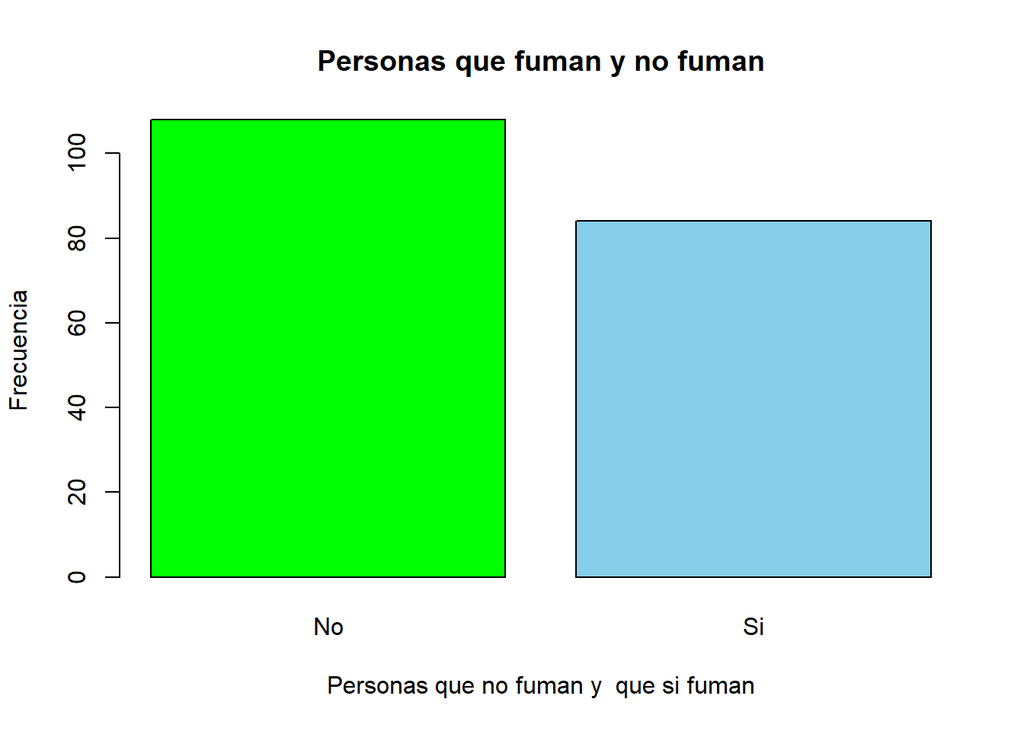

```r
barplot(Tabla3, benside = F,
        main = 'Personas que fuman y no fuman',
        xlab = 'Personas que no fuman y  que si fuman', horiz = FALSE,
        ylab = 'Frecuencia',
        col = c("green", "sky blue"))
```

## 8.8 Construir una tabla de frecuencias cruzadas entre dos variables categóricas y su correspondiente diagrama de barras

```r
#Definiendo y convirtiendo en factor
Fuma <- as.factor(MisDatos$Fuma)
Clases <- as.factor((MisDatos$Clases))

#Tabla de frecuencias con table
Tabla4 <- table(Clases,Fuma); Tabla4
```

```
##             Fuma
## Clases       No Si
##   Presencial 73 51
##   Virtual    35 33
```

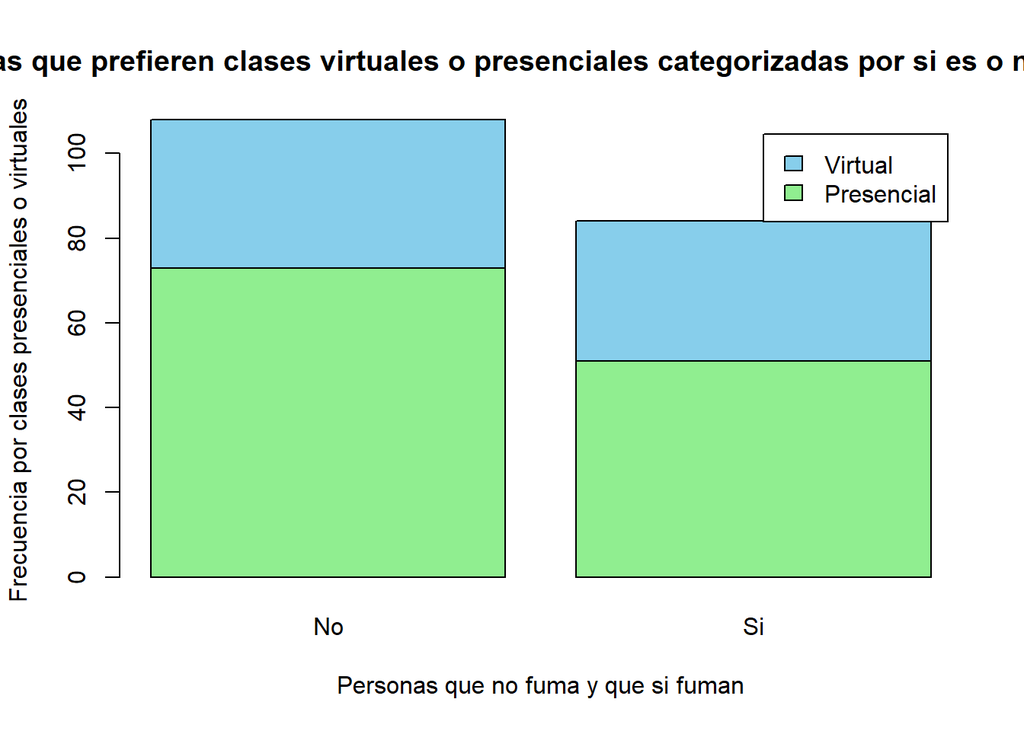

```r
barplot(Tabla4, benside = F,
        main = 'Personas que prefieren clases virtuales o presenciales categorizadas por si es o no fumadora',
        xlab = 'Personas que no fuma y que si fuman', horiz = FALSE,
        ylab = 'Frecuencia por clases presenciales o virtuales',
        legend = c ("Presencial", "Virtual"),
        col = c("Light green", "sky blue"))
```

## 8.9 Considerar una variable numérica (que no sea P3, ni Edad) y calcular las medidas estadísticas siguientes:

### 8.9.1 min(x)

```r
final <- MisDatos$Final
final
```

```
##   [1] 3.3 1.9 2.5 3.0 5.0 3.6 4.3 1.9 5.0 2.9 2.3 3.0 4.8 2.7 4.2 4.2 3.4 4.0
##  [19] 4.1 2.5 5.0 3.5 2.0 2.3 4.8 2.4 5.0 3.0 4.8 4.3 5.0 4.6 3.1 3.6 2.0 3.0
##  [37] 2.9 3.2 3.4 2.4 3.6 4.9 2.2 3.5 1.3 1.9 2.7 2.5 3.0 2.4 2.7 4.0 1.9 3.5
##  [55] 3.0 3.3 3.3 4.9 3.0 1.6 2.5 3.7 4.4 4.1 4.1 3.4 3.7 2.5 2.8 2.0 4.4 2.1
##  [73] 1.8 2.7 3.8 4.1 3.1 3.6 4.6 4.3 3.4 3.9 3.3 4.3 4.1 3.6 4.4 2.2 3.9 2.5
##  [91] 4.4 3.1 2.8 4.0 3.4 4.0 4.3 3.9 4.0 3.5 2.4 2.3 2.2 4.5 3.1 4.0 4.0 5.0
## [109] 3.3 3.3 3.9 4.0 3.0 2.5 3.7 4.0 4.5 4.0 4.6 4.5 2.4 2.5 2.1 5.0 4.3 1.5
## [127] 1.8 4.0 4.0 5.0 4.5 3.1 2.9 2.1 2.1 2.3 3.4 2.6 2.5 2.2 3.7 2.5 2.6 2.2
## [145] 3.0 2.6 2.9 3.1 2.7 3.1 3.4 2.4 3.5 2.6 2.6 2.3 3.7 2.3 2.7 2.6 3.3 3.4
## [163] 3.6 3.5 3.9 3.6 2.6 2.5 2.7 4.3 3.2 3.3 3.0 4.7 3.2 3.3 3.0 3.8 3.2 3.4
## [181] 3.8 3.5 4.0 4.2 3.3 4.4 3.0 3.1 2.7 4.7 3.1 3.0
```

```r
min(final)
```

```
## [1] 1.3
```

### 8.9.2 max(x)

```r
max(final)
```

```
## [1] 5
```

### 8.9.3 range(x)

```r
range(final)
```

```
## [1] 1.3 5.0
```

### 8.9.4 lenght(x)

```r
length(final)
```

```
## [1] 192
```

### 8.9.5 sum(x)

```r
sum(final)
```

```
## [1] 638.7
```

### 8.9.6 mean(x)

```r
mean(final)
```

```
## [1] 3.326563
```

### 8.9.7 median(x)

```r
median(final)
```

```
## [1] 3.3
```

### 8.9.8 var(x)

```r
var(final)
```

```
## [1] 0.7605996
```

### 8.9.9 sqrt(var(x))

```r
sqrt(var(final))
```

```
## [1] 0.8721236
```

### 8.9.10 sd(x)

```r
sd(final)
```

```
## [1] 0.8721236
```

```r
#skewness(final)
```

## 8.10 A partir del subconjunto genera una gráfica de barras, una de dispersión y un histograma. Deberás explicar el resultado de cada gráfica

### 8.10.1 Gráfica de barras

```r
#Definiendo y convirtiendo en factor
Financiacion <- as.factor(MisDatos$Financiacion)
Fuma <- as.factor((MisDatos$Fuma))

#Tabla de frecuencias con table
Tabla5 <- table(Fuma,Financiacion); Tabla5
```

```
##     Financiacion
## Fuma Beca Credito Otro
##   No   65      43    0
##   Si   69      12    3
```

[figure not shown]

```r
barplot(Tabla5, benside = F,
        main = 'Financiación de las personas de acuerdo a su edad',
        xlab = 'Tipo de financiación', horiz = FALSE,
        ylab = 'Frecuencia en no fuma y si fuma',
        legend = c ("No Fuma", "Fuma"),
        col = c("Light green", "sky blue", "orange"))
```

En esta gráfica de barras es interesante ya que, podemos observar que a los estudiantes que no fuman podrían tener la opción de adquirir o postularse para una beca y a un crédito. En cambio, los estudiantes que tienen el habito de fumar el índice de que adquieran una beca es casi similar al de los que no fuman, sin embargo el índice de que se postulen para un crédito es mucho más bajo en comparación a los que no fuma y tienen que buscar otras opciones.

### 8.10.2 Gráfica de dispersión

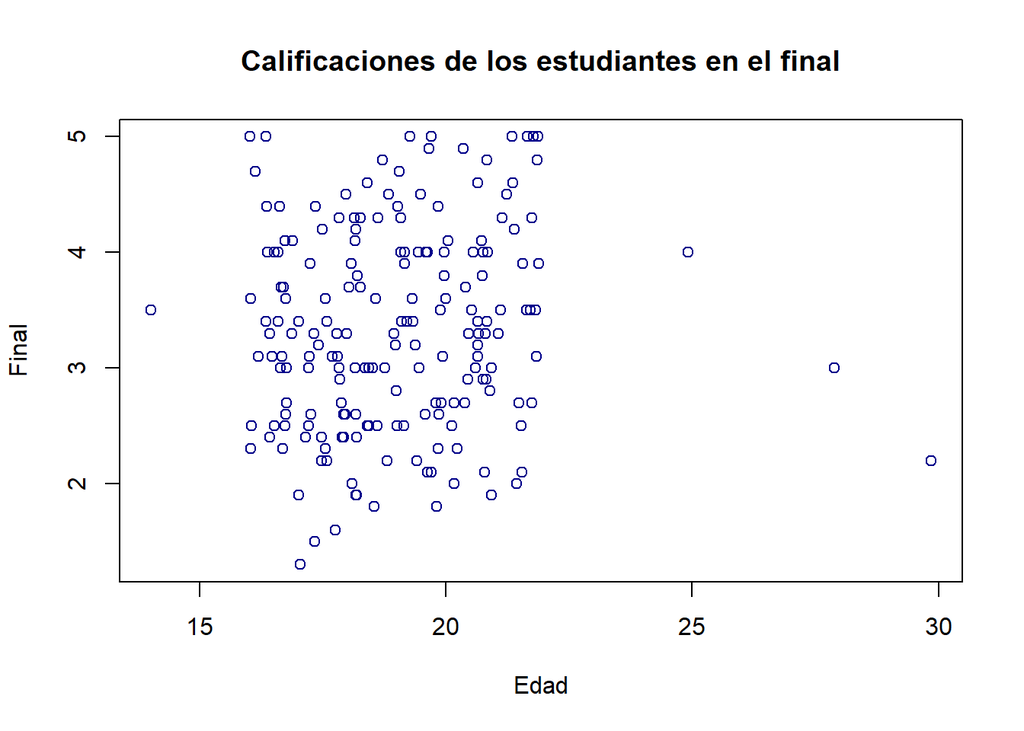

```r
plot(MisDatos$Edad,MisDatos$Final,
     main="Calificaciones de los estudiantes en el final",
     xlab="Edad",
     ylab="Final",
     col = "dark blue")
```

En esta gráfica de dispersión podemos notar que las calificaciones de los alumnos no son tan buenas de acuerdo a su edad, se puede ver que entre las edades de 15 a 25 las calificaciones se centran entre 2 al 5.

## 8.11 Histograma

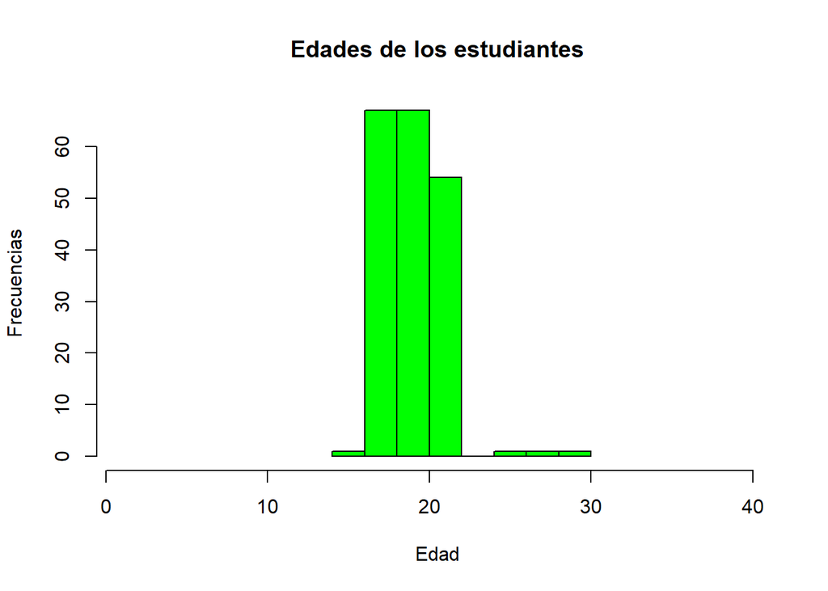

```r
hist(MisDatos$Edad, main = "Edades de los estudiantes",
     xlab = "Edad",
     ylab = "Frecuencias",
     #xlim = c(100,200), col = "yellow",
     xlim = c(1,40), col = "green",
     freq = TRUE)
```

En este histograma se observa que el rango en donde se concentra la mayoria de las edades de los estudiantes esta de lo 15 a lo 25 años de edad, asi como también el donde se encuentra el menor rango de edad esta en menores de 15 años y mayores de 25 a 30 años de edad.